```python
import pandas as pd
import seaborn as sns
import matplotlib.pyplot as plt
import numpy as np
from matplotlib.pyplot import subplots_adjust
```

URL for video https://drive.google.com/open?id=15trga_gwy7cbXUsb8RW6OK7GeXe20yue

URL for report https://drive.google.com/open?id=1IjPuLYil6yaXf_o1ly4rbdQngi0ZbwHGu644hOPKXOo

# Section 1: Context and description of the data

This dataset explores the chemical features and quality measurements of the *vinho verde* wine. The vinho verde wine is a unique product from the north-west region of Portugal that accounts for 15% of all Portuguese wine production. It is known to have medium amounts of alcohol and being particularly popular during the summer due to its fruity floral aroma. Though more commonly found as a white wine, the dataset contains both white and red variations.

The data was collected from May 2004 to February 2007 by the CVRVV, an organization dedicated to studying the vinho verde wine. Only samples assigned to the "protected designation of origin" (PDO) title were used. The PDO designation refers to a European Union specialization that is used to protect the quality of agricultural products. Thus, we can see that the samples used in this dataset consist of high quality wines, though they may not be representative of all vinho verde wines.

The chemical features of the samples were measured in a lab resulting in 11 variables including: acidity, sugar, chlorides, sulfur dioxide levels, density, pH, sulphates, and alcohol content. Quality of each wine was evaluated by taking the median of three blind taste test scores that ranged from 0 (very bad) to 10 (excellent). Though the data initially separated the white and red wines, we combined the two datasets in order to examine the differences between their chemical compositions. This resulted in a total of 6497 observations with 4898 white and 1599 red.

## 1.1 Basic Data Cleaning

In this section, we loaded the red and white wine datasets and combined the two together, so that we could later create the prediction model based on the color variable.

```python
red = pd.read_csv('/Users/Dingsn/Desktop/winequality-red.csv', sep=';')
```

```python
red.shape
```

```
(1599, 12)
```

```python
white = pd.read_csv('/Users/Dingsn/Desktop/winequality-white.csv', sep=';')
```

```python
white.shape
```

```
(4898, 12)
```

```python
wine = pd.concat([red, white])
```

```python
wine.shape
```

```
(6497, 12)
```

```python
wine['color'] = "RED"
wine.color[1599:6497] = "WHITE"
```

# Section 2: EDA

```python
print(wine.describe())
```

```
       fixed acidity  volatile acidity  citric acid  residual sugar  \
count    6497.000000       6497.000000  6497.000000     6497.000000
mean        7.215307          0.339666     0.318633        5.443235
std         1.296434          0.164636     0.145318        4.757804
min         3.800000          0.080000     0.000000        0.600000
25%         6.400000          0.230000     0.250000        1.800000
50%         7.000000          0.290000     0.310000        3.000000
75%         7.700000          0.400000     0.390000        8.100000
max        15.900000          1.580000     1.660000       65.800000

         chlorides  free sulfur dioxide  total sulfur dioxide      density  \
count  6497.000000          6497.000000           6497.000000  6497.000000
mean      0.056034            30.525319            115.744574     0.994697
std       0.035034            17.749400             56.521855     0.002999
min       0.009000             1.000000              6.000000     0.987110
25%       0.038000            17.000000             77.000000     0.992340
50%       0.047000            29.000000            118.000000     0.994890
75%       0.065000            41.000000            156.000000     0.996990
max       0.611000           289.000000            440.000000     1.038980

                pH    sulphates      alcohol      quality
count  6497.000000  6497.000000  6497.000000  6497.000000
mean      3.218501     0.531268    10.491801     5.818378
std       0.160787     0.148806     1.192712     0.873255
min       2.720000     0.220000     8.000000     3.000000
25%       3.110000     0.430000     9.500000     5.000000
50%       3.210000     0.510000    10.300000     6.000000
75%       3.320000     0.600000    11.300000     6.000000
max       4.010000     2.000000    14.900000     9.000000
```

## 2.1 Color

In this section, we were interested in examining whether the chemical compositions differed between the red and white wines.

### 2.1.1 Graphs

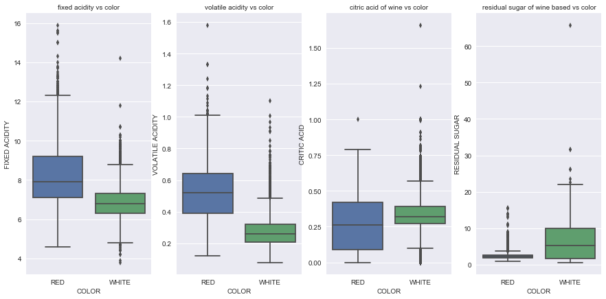

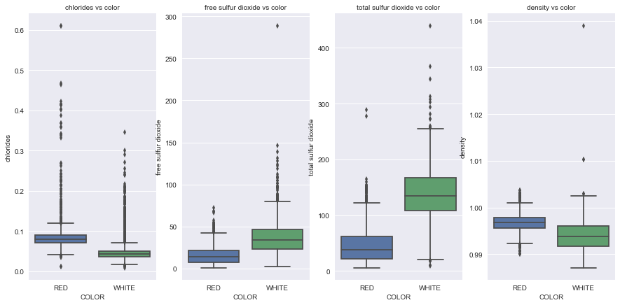

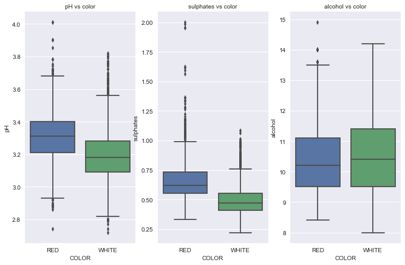

```python
subplots_adjust(wspace=0.5,hspace=0.5)
plt.subplots(figsize=(15,7))
plt.subplot(1,4,1)
plot = sns.boxplot(x="color", y="fixed acidity", data=wine)
plot.set_title("fixed acidity vs color",fontsize=10)
plot.set_xlabel("COLOR",fontsize=10)
plot.set_ylabel("FIXED ACIDITY",fontsize=10)
plt.subplot(1,4,2)
plot2 = sns.boxplot(x="color", y="volatile acidity", data=wine)
plot2.set_title("volatile acidity vs color",fontsize=10)
plot2.set_xlabel("COLOR",fontsize=10)
plot2.set_ylabel("VOLATILE ACIDITY",fontsize=10)
plt.subplot(1,4,3)
plot4 = sns.boxplot(x="color", y="citric acid", data=wine)
plot4.set_title("citric acid of wine vs color",fontsize=10)
plot4.set_xlabel("COLOR",fontsize=10)
plot4.set_ylabel("CRITIC ACID",fontsize=10)
plt.subplot(1,4,4)
plot6 = sns.boxplot(x="color", y="residual sugar", data=wine)
plot6.set_title("residual sugar of wine based vs color",fontsize=10)
plot6.set_xlabel("COLOR",fontsize=10)
plot6.set_ylabel("RESIDUAL SUGAR",fontsize=10)
plt.show()

subplots_adjust(wspace=0.5,hspace=0.5)
plt.subplots(figsize=(15,7))
plt.subplot(1,4,1)
plot = sns.boxplot(x="color", y="chlorides", data=wine)
plot.set_title("chlorides vs color",fontsize=10)
plot.set_xlabel("COLOR",fontsize=10)
plot.set_ylabel("chlorides",fontsize=10)
plt.subplot(1,4,2)
plot2 = sns.boxplot(x="color", y="free sulfur dioxide", data=wine)
plot2.set_title("free sulfur dioxide vs color",fontsize=10)
plot2.set_xlabel("COLOR",fontsize=10)
plot2.set_ylabel("free sulfur dioxide",fontsize=10)
plt.subplot(1,4,3)
plot4 = sns.boxplot(x="color", y="total sulfur dioxide", data=wine)
plot4.set_title("total sulfur dioxide vs color",fontsize=10)
plot4.set_xlabel("COLOR",fontsize=10)
plot4.set_ylabel("total sulfur dioxide",fontsize=10)
plt.subplot(1,4,4)
plot6 = sns.boxplot(x="color", y="density", data=wine)
plot6.set_title("density vs color",fontsize=10)
plot6.set_xlabel("COLOR",fontsize=10)
plot6.set_ylabel("density",fontsize=10)
plt.show()

subplots_adjust(wspace=0.5,hspace=0.5)
plt.subplots(figsize=(15,7))
plt.subplot(1,4,1)
plot = sns.boxplot(x="color", y="pH", data=wine)
plot.set_title("pH vs color",fontsize=10)
plot.set_xlabel("COLOR",fontsize=10)
plot.set_ylabel("pH",fontsize=10)
plt.subplot(1,4,2)
plot2 = sns.boxplot(x="color", y="sulphates", data=wine)
plot2.set_title("sulphates vs color",fontsize=10)
plot2.set_xlabel("COLOR",fontsize=10)
plot2.set_ylabel("sulphates",fontsize=10)
plt.subplot(1,4,3)
plot4 = sns.boxplot(x="color", y="alcohol", data=wine)
plot4.set_title("alcohol vs color",fontsize=10)
plot4.set_xlabel("COLOR",fontsize=10)
plot4.set_ylabel("alcohol",fontsize=10)

plt.show()
```

### 2.1.2 ANOVA

```python
import statsmodels.api as sm
import statsmodels.formula.api as smf
```

```python
wine_anova = wine.copy()
wine_anova.columns = wine.columns.str.strip().str.lower().str.replace(' ', '_').str.replace('(', '').str.replace(')', '')
wine_anova['quality'] = wine_anova['quality'].map({3:'LOW',4: 'LOW', 5: 'MED',6: 'MED',7: 'HIGH',8: 'HIGH',9:'HIGH'})
```

```python
wine_anova.head()
```

|  | fixed_acidity | volatile_acidity | citric_acid | residual_sugar | chlorides | free_sulfur_dioxide | total_sulfur_dioxide | density | ph | sulphates | alcohol | quality | color |
| --- | --- | --- | --- | --- | --- | --- | --- | --- | --- | --- | --- | --- | --- |
| 0 | 7.4 | 0.70 | 0.00 | 1.9 | 0.076 | 11.0 | 34.0 | 0.9978 | 3.51 | 0.56 | 9.4 | MED | RED |
| 1 | 7.8 | 0.88 | 0.00 | 2.6 | 0.098 | 25.0 | 67.0 | 0.9968 | 3.20 | 0.68 | 9.8 | MED | RED |
| 2 | 7.8 | 0.76 | 0.04 | 2.3 | 0.092 | 15.0 | 54.0 | 0.9970 | 3.26 | 0.65 | 9.8 | MED | RED |
| 3 | 11.2 | 0.28 | 0.56 | 1.9 | 0.075 | 17.0 | 60.0 | 0.9980 | 3.16 | 0.58 | 9.8 | MED | RED |
| 4 | 7.4 | 0.70 | 0.00 | 1.9 | 0.076 | 11.0 | 34.0 | 0.9978 | 3.51 | 0.56 | 9.4 | MED | RED |

```python
fix_acid_model = sm.stats.anova_lm(smf.ols('fixed_acidity ~ color', data = wine_anova).fit())
vol_acid_model = sm.stats.anova_lm(smf.ols('volatile_acidity ~ color', data = wine_anova).fit())
cit_acid_model = sm.stats.anova_lm(smf.ols('citric_acid ~ color', data = wine_anova).fit())
res_sugar_model = sm.stats.anova_lm(smf.ols('residual_sugar ~ color', data = wine_anova).fit())
chl_model = sm.stats.anova_lm(smf.ols('chlorides ~ color', data = wine_anova).fit())
free_sulf_model = sm.stats.anova_lm(smf.ols('free_sulfur_dioxide ~ color', data = wine_anova).fit())
tot_sulf_model = sm.stats.anova_lm(smf.ols('total_sulfur_dioxide ~ color', data = wine_anova).fit())
density_model = sm.stats.anova_lm(smf.ols('density ~ color', data = wine_anova).fit())
ph_model = sm.stats.anova_lm(smf.ols('ph ~ color', data = wine_anova).fit())
sulph_model = sm.stats.anova_lm(smf.ols('sulphates ~ color', data = wine_anova).fit())
alc_model = sm.stats.anova_lm(smf.ols('alcohol ~ color', data = wine_anova).fit())
```

```python
names=wine.columns.values[0:11]
p = np.asarray([fix_acid_model['PR(>F)'].color,
     vol_acid_model['PR(>F)'].color,
     cit_acid_model['PR(>F)'].color,
     res_sugar_model['PR(>F)'].color,
     chl_model['PR(>F)'].color,
     free_sulf_model['PR(>F)'].color,
     tot_sulf_model['PR(>F)'].color,
     density_model['PR(>F)'].color,
     ph_model['PR(>F)'].color,
     sulph_model['PR(>F)'].color,
     alc_model['PR(>F)'].color])

sig = np.where(p < 0.05, "significant", "not significant")

ps = pd.DataFrame({'p':p, 'significance':sig}, index=names)
ps
```

|  | p | significance |
| --- | --- | --- |
| fixed acidity | 0.000000e+00 | significant |
| volatile acidity | 0.000000e+00 | significant |
| citric acid | 2.003736e-52 | significant |
| residual sugar | 2.959354e-185 | significant |
| chlorides | 0.000000e+00 | significant |
| free sulfur dioxide | 0.000000e+00 | significant |
| total sulfur dioxide | 0.000000e+00 | significant |
| density | 7.319605e-236 | significant |
| pH | 5.923308e-164 | significant |
| sulphates | 0.000000e+00 | significant |
| alcohol | 7.867874e-03 | significant |

Looking at the ANOVA results, we can see that there is a significant difference between red and white wines for all predictors, confirming our observations from the boxplots.

## 2.2 Quality

### 2.2.1 Graphs

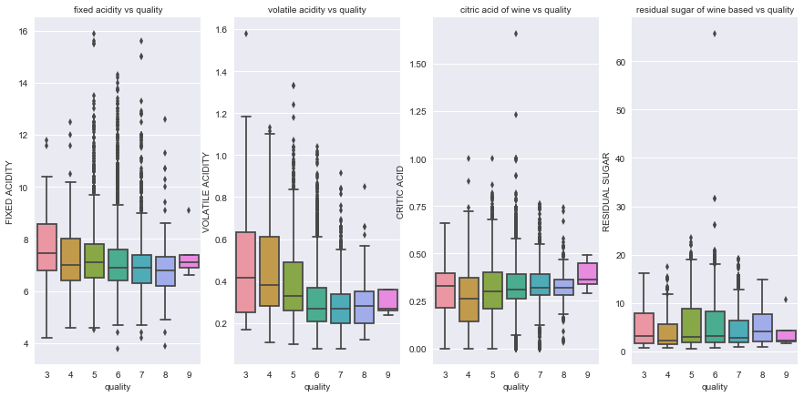

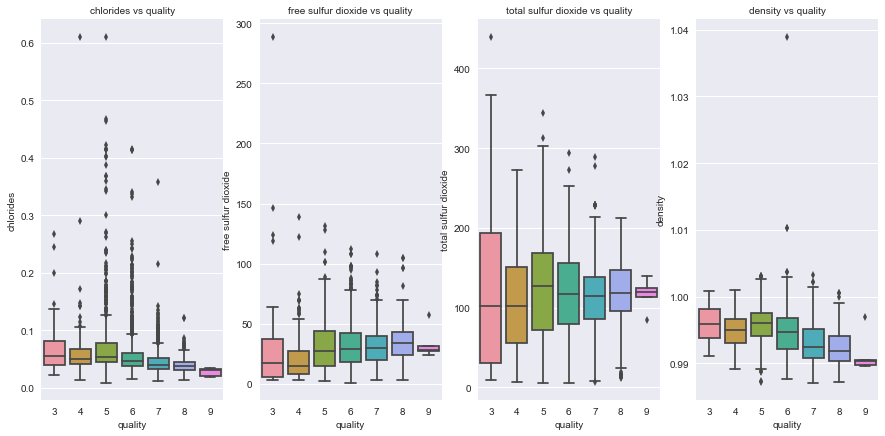

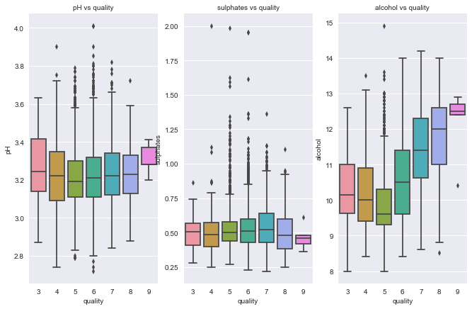

```python
subplots_adjust(wspace=0.5,hspace=0.5)
plt.subplots(figsize=(15,7))
plt.subplot(1,4,1)
plot = sns.boxplot(x="quality", y="fixed acidity", data=wine)
plot.set_title("fixed acidity vs quality",fontsize=10)
plot.set_xlabel("quality",fontsize=10)
plot.set_ylabel("FIXED ACIDITY",fontsize=10)
plt.subplot(1,4,2)
plot2 = sns.boxplot(x="quality", y="volatile acidity", data=wine)
plot2.set_title("volatile acidity vs quality",fontsize=10)
plot2.set_xlabel("quality",fontsize=10)
plot2.set_ylabel("VOLATILE ACIDITY",fontsize=10)
plt.subplot(1,4,3)
plot4 = sns.boxplot(x="quality", y="citric acid", data=wine)
plot4.set_title("citric acid of wine vs quality",fontsize=10)
plot4.set_xlabel("quality",fontsize=10)
plot4.set_ylabel("CRITIC ACID",fontsize=10)
plt.subplot(1,4,4)
plot6 = sns.boxplot(x="quality", y="residual sugar", data=wine)
plot6.set_title("residual sugar of wine based vs quality",fontsize=10)
plot6.set_xlabel("quality",fontsize=10)
plot6.set_ylabel("RESIDUAL SUGAR",fontsize=10)
plt.show()

subplots_adjust(wspace=0.5,hspace=0.5)
plt.subplots(figsize=(15,7))
plt.subplot(1,4,1)
plot = sns.boxplot(x="quality", y="chlorides", data=wine)
plot.set_title("chlorides vs quality",fontsize=10)
plot.set_xlabel("quality",fontsize=10)
plot.set_ylabel("chlorides",fontsize=10)
plt.subplot(1,4,2)
plot2 = sns.boxplot(x="quality", y="free sulfur dioxide", data=wine)
plot2.set_title("free sulfur dioxide vs quality",fontsize=10)
plot2.set_xlabel("quality",fontsize=10)
plot2.set_ylabel("free sulfur dioxide",fontsize=10)
plt.subplot(1,4,3)
plot4 = sns.boxplot(x="quality", y="total sulfur dioxide", data=wine)
plot4.set_title("total sulfur dioxide vs quality",fontsize=10)
plot4.set_xlabel("quality",fontsize=10)
plot4.set_ylabel("total sulfur dioxide",fontsize=10)
plt.subplot(1,4,4)
plot6 = sns.boxplot(x="quality", y="density", data=wine)
plot6.set_title("density vs quality",fontsize=10)
plot6.set_xlabel("quality",fontsize=10)
plot6.set_ylabel("density",fontsize=10)
plt.show()

subplots_adjust(wspace=0.5,hspace=0.5)
plt.subplots(figsize=(15,7))
plt.subplot(1,4,1)
plot = sns.boxplot(x="quality", y="pH", data=wine)
plot.set_title("pH vs quality",fontsize=10)
plot.set_xlabel("quality",fontsize=10)
plot.set_ylabel("pH",fontsize=10)
plt.subplot(1,4,2)
plot2 = sns.boxplot(x="quality", y="sulphates", data=wine)
plot2.set_title("sulphates vs quality",fontsize=10)
plot2.set_xlabel("quality",fontsize=10)
plot2.set_ylabel("sulphates",fontsize=10)
plt.subplot(1,4,3)
plot4 = sns.boxplot(x="quality", y="alcohol", data=wine)
plot4.set_title("alcohol vs quality",fontsize=10)
plot4.set_xlabel("quality",fontsize=10)
plot4.set_ylabel("alcohol",fontsize=10)

plt.show()
```

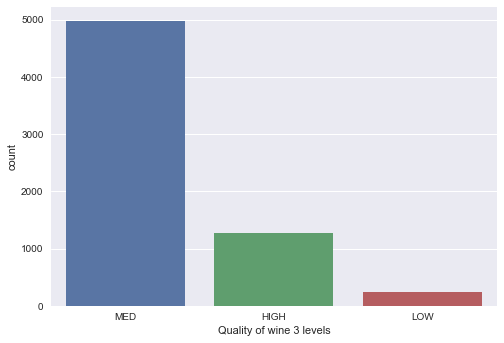

```python
wine2=wine.copy()

wine2['quality'] = wine2['quality'].map({3:'LOW',4: 'LOW', 5: 'MED',6: 'MED',7: 'HIGH',8: 'HIGH',9:'HIGH'})
sns.countplot(x="quality", data=wine2)
plt.xlabel("Quality of wine 3 levels")
plt.show()
#wine2.quality[wine2.quality >4 & wine2.quality<7]   = "MED"
#wine2.quality[wine2.quality >=7]   = "High"
```

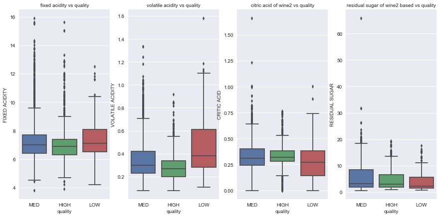

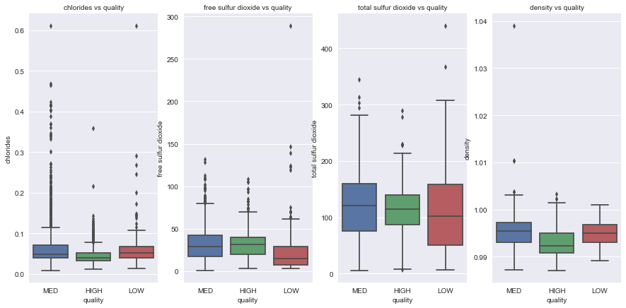

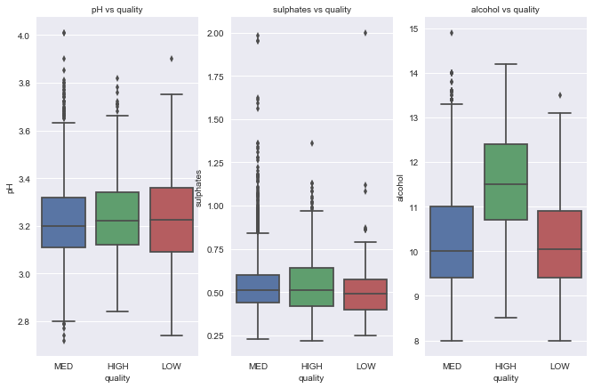

```python
subplots_adjust(wspace=0.5,hspace=0.5)
plt.subplots(figsize=(15,7))
plt.subplot(1,4,1)
plot = sns.boxplot(x="quality", y="fixed acidity", data=wine2)
plot.set_title("fixed acidity vs quality",fontsize=10)
plot.set_xlabel("quality",fontsize=10)
plot.set_ylabel("FIXED ACIDITY",fontsize=10)
plt.subplot(1,4,2)
plot2 = sns.boxplot(x="quality", y="volatile acidity", data=wine2)
plot2.set_title("volatile acidity vs quality",fontsize=10)
plot2.set_xlabel("quality",fontsize=10)
plot2.set_ylabel("VOLATILE ACIDITY",fontsize=10)
plt.subplot(1,4,3)
plot4 = sns.boxplot(x="quality", y="citric acid", data=wine2)
plot4.set_title("citric acid of wine2 vs quality",fontsize=10)
plot4.set_xlabel("quality",fontsize=10)
plot4.set_ylabel("CRITIC ACID",fontsize=10)
plt.subplot(1,4,4)
plot6 = sns.boxplot(x="quality", y="residual sugar", data=wine2)
plot6.set_title("residual sugar of wine2 based vs quality",fontsize=10)
plot6.set_xlabel("quality",fontsize=10)
plot6.set_ylabel("RESIDUAL SUGAR",fontsize=10)
plt.show()

subplots_adjust(wspace=0.5,hspace=0.5)
plt.subplots(figsize=(15,7))
plt.subplot(1,4,1)
plot = sns.boxplot(x="quality", y="chlorides", data=wine2)
plot.set_title("chlorides vs quality",fontsize=10)
plot.set_xlabel("quality",fontsize=10)
plot.set_ylabel("chlorides",fontsize=10)
plt.subplot(1,4,2)
plot2 = sns.boxplot(x="quality", y="free sulfur dioxide", data=wine2)
plot2.set_title("free sulfur dioxide vs quality",fontsize=10)
plot2.set_xlabel("quality",fontsize=10)
plot2.set_ylabel("free sulfur dioxide",fontsize=10)
plt.subplot(1,4,3)
plot4 = sns.boxplot(x="quality", y="total sulfur dioxide", data=wine2)
plot4.set_title("total sulfur dioxide vs quality",fontsize=10)
plot4.set_xlabel("quality",fontsize=10)
plot4.set_ylabel("total sulfur dioxide",fontsize=10)
plt.subplot(1,4,4)
plot6 = sns.boxplot(x="quality", y="density", data=wine2)
plot6.set_title("density vs quality",fontsize=10)
plot6.set_xlabel("quality",fontsize=10)
plot6.set_ylabel("density",fontsize=10)
plt.show()

subplots_adjust(wspace=0.5,hspace=0.5)
plt.subplots(figsize=(15,7))
plt.subplot(1,4,1)
plot = sns.boxplot(x="quality", y="pH", data=wine2)
plot.set_title("pH vs quality",fontsize=10)
plot.set_xlabel("quality",fontsize=10)
plot.set_ylabel("pH",fontsize=10)
plt.subplot(1,4,2)
plot2 = sns.boxplot(x="quality", y="sulphates", data=wine2)
plot2.set_title("sulphates vs quality",fontsize=10)
plot2.set_xlabel("quality",fontsize=10)
plot2.set_ylabel("sulphates",fontsize=10)
plt.subplot(1,4,3)
plot4 = sns.boxplot(x="quality", y="alcohol", data=wine2)
plot4.set_title("alcohol vs quality",fontsize=10)
plot4.set_xlabel("quality",fontsize=10)
plot4.set_ylabel("alcohol",fontsize=10)

plt.show()
```

We can see from the bargraph that there are significantly more observations of medium quality wine compared to the low and high quality wines.

Looking at the boxplots, we can see there are clear differences in means in some of the variables, such as alcohol, volatile acidity and density among the quality levels. For some of the variables, boxplots do not show clear difference in means, but the ANOVA test conducted in the next section suggests that there are significant differences in means for all the variables. Like the boxplots for color, we can see there are many outliers in the predictors for quality as well.

### 2.2.2 ANOVA

```python
fix_acid_model = sm.stats.anova_lm(smf.ols('fixed_acidity ~ quality', data = wine_anova).fit())
vol_acid_model = sm.stats.anova_lm(smf.ols('volatile_acidity ~ quality', data = wine_anova).fit())
cit_acid_model = sm.stats.anova_lm(smf.ols('citric_acid ~ quality', data = wine_anova).fit())
res_sugar_model = sm.stats.anova_lm(smf.ols('residual_sugar ~ quality', data = wine_anova).fit())
chl_model = sm.stats.anova_lm(smf.ols('chlorides ~ quality', data = wine_anova).fit())
free_sulf_model = sm.stats.anova_lm(smf.ols('free_sulfur_dioxide ~ quality', data = wine_anova).fit())
tot_sulf_model = sm.stats.anova_lm(smf.ols('total_sulfur_dioxide ~ quality', data = wine_anova).fit())
density_model = sm.stats.anova_lm(smf.ols('density ~ quality', data = wine_anova).fit())
ph_model = sm.stats.anova_lm(smf.ols('ph ~ quality', data = wine_anova).fit())
sulph_model = sm.stats.anova_lm(smf.ols('sulphates ~ quality', data = wine_anova).fit())
alc_model = sm.stats.anova_lm(smf.ols('alcohol ~ quality', data = wine_anova).fit())
```

```python
names=wine2.columns.values[0:11]
p = np.asarray([fix_acid_model['PR(>F)'].quality,
     vol_acid_model['PR(>F)'].quality,
     cit_acid_model['PR(>F)'].quality,
     res_sugar_model['PR(>F)'].quality,
     chl_model['PR(>F)'].quality,
     free_sulf_model['PR(>F)'].quality,
     tot_sulf_model['PR(>F)'].quality,
     density_model['PR(>F)'].quality,
     ph_model['PR(>F)'].quality,
     sulph_model['PR(>F)'].quality,
     alc_model['PR(>F)'].quality])

sig = np.where(p < 0.05, "significant", "not significant")

ps = pd.DataFrame({'p':p, 'significance':sig}, index=names)
ps
```

|  | p | significance |
| --- | --- | --- |
| fixed acidity | 1.374456e-04 | significant |
| volatile acidity | 6.418327e-61 | significant |
| citric acid | 1.803415e-09 | significant |
| residual sugar | 7.526355e-11 | significant |
| chlorides | 1.238110e-38 | significant |
| free sulfur dioxide | 4.638491e-11 | significant |
| total sulfur dioxide | 9.479730e-07 | significant |
| density | 3.658317e-112 | significant |
| pH | 1.370108e-02 | significant |
| sulphates | 1.062688e-03 | significant |
| alcohol | 2.676678e-234 | significant |

As mentioned above, we can see from the ANOVA results that all the variables had significant differences in their means between the three quality levels.

## 2.3 Examining relationship between predictors

In addition to comparing the predictors against the response variables (color, quality), we wanted to find any relations between the predictors themselves. This section uses scatter matrices, correlation heatmaps and barplots to explore this.

### 2.3.1 Scatter Matrix

```python
sns.pairplot(wine.loc[:,wine.columns != 'quality'], hue='color')
```

### 2.3.2 Correlation Heat Map

```python
corr=wine.corr()
```

[figure not shown]

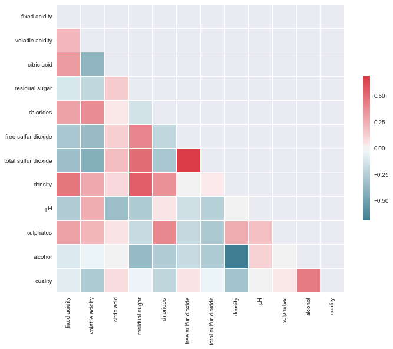

```python
mask = np.zeros_like(corr, dtype=np.bool)
mask[np.triu_indices_from(mask)] = True
f, ax = plt.subplots(figsize=(11, 9))
cmap = sns.diverging_palette(220, 10, as_cmap=True)
sns.heatmap(corr, mask=mask, cmap=cmap, vmax=.3, center=0,square=True, linewidths=.5, cbar_kws={"shrink": .5})
plt.show()
```

### 2.3.3 Bar plots

We created bar plots of the mean values for each variable in order to more clearly see how each chemical property differed between color as well as how they affected wine quality.

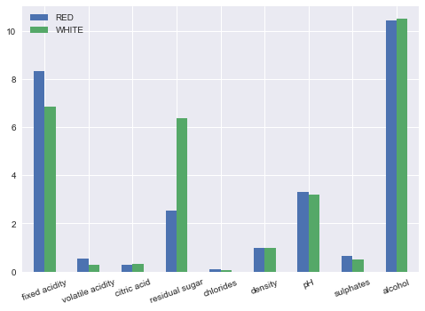

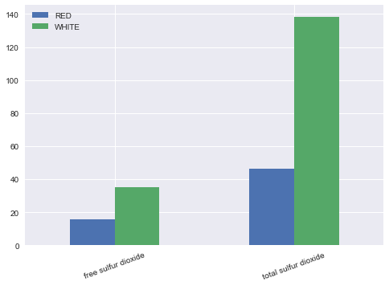

```python
A=wine.groupby('color', as_index=False).mean()

A1=A.transpose()
A1.columns=['RED','WHITE']
A2=A1.iloc[[1,2,3,4,5,8,9,10,11],:]

A2.plot.bar(y=['RED','WHITE'],rot=20)
plt.show()
A3=A1.iloc[6:8,:]

A3.plot.bar(y=['RED','WHITE'],rot=20)
plt.show()
```

[figure not shown]

[figure not shown]

```python
C=wine2.groupby('quality', as_index=False).mean()

C1=C.transpose()
C1.columns=['Low','Med','High']
C2=C1.iloc[[1,2,3,4,5,8,9,10,11],:]

C2.plot.bar(y=['Low','Med','High'],rot=20)
plt.show()
C3=C1.iloc[6:8,:]

C3.plot.bar(y=['Low','Med','High'],rot=20)
plt.show()
```

# Section 3: Predictive Modeling

## 3.1 Quality prediction

### 3.1.1 Linear regression: quality (red wines)

```python
from sklearn.linear_model import LinearRegression
from sklearn.cross_validation import train_test_split
features = ['fixed acidity', 'volatile acidity', 'citric acid', 'residual sugar','chlorides', 'free sulfur dioxide', 'total sulfur dioxide', 'density','pH', 'sulphates', 'alcohol']
x = red[features]
y = red['quality']
x_train,x_test,y_train,y_test=train_test_split(x,y,random_state=3)
regressor = LinearRegression()
regressor.fit(x_train,y_train)
accuracy = regressor.score(x_test, y_test)
"Accuracy: {}%".format(int(round(accuracy * 100)))
```

```
'Accuracy: 38%'
```

```python
model=regressor.fit(x_train,y_train)
```

```python
print(model.intercept_,model.coef_)
```

```
(9.9828333315168454, array([  2.32736478e-02,  -9.91535569e-01,  -1.41267594e-01,
         8.11925585e-03,  -1.59192407e+00,   5.50005690e-03,
        -3.54198549e-03,  -6.06916616e+00,  -4.06325022e-01,
         8.23603060e-01,   2.94180891e-01]))
```

### 3.1.2 Linear regression: quality (white wines)

```python
x1 = white[features]
y1 = white['quality']
x_train,x_test,y_train,y_test=train_test_split(x1,y1,random_state=3)
regressor = LinearRegression()
regressor.fit(x_train,y_train)
accuracy = regressor.score(x_test, y_test)
"Accuracy: {}%".format(int(round(accuracy * 100)))
```

```
'Accuracy: 28%'
```

For linear reg, the model does not do a good job with only 38% accuracy for red wines and only 28% for white wines, meaning there is no clear linear relationship between quality and other variables.

### 3.1.3 Random Forest

```python
from sklearn.model_selection import train_test_split
from sklearn.ensemble import RandomForestClassifier
np.random.seed(0)
train, test = train_test_split(wine2, test_size = 0.5, random_state = 42)
features = wine2.drop(['quality','color'],axis=1).columns[:]
#y = pd.factorize(train['quality'])[0]
y=train['quality']
clf = RandomForestClassifier(n_jobs=2, random_state=0)
clf.fit(train[features], y)
pred_rf=clf.predict(test[features])
#predics=np.where(preds==0, 'RED','WHITE')
crosstbl=pd.crosstab(test['quality'], pred_rf, rownames=['Actual Quality'], colnames=['Predicted Quality'])
crosstbl
```

| Predicted Quality Actual Quality | HIGH | LOW | MED |
| --- | --- | --- | --- |
| HIGH | 338 | 0 | 298 |
| LOW | 4 | 13 | 115 |
| MED | 175 | 13 | 2293 |

```python
list(zip(train[features], clf.feature_importances_))
```

```
[('fixed acidity', 0.075168405781974507),
 ('volatile acidity', 0.085870889688137261),
 ('citric acid', 0.075851271653996716),
 ('residual sugar', 0.0845621059824683),
 ('chlorides', 0.081321461449435625),
 ('free sulfur dioxide', 0.081736875026123409),
 ('total sulfur dioxide', 0.088607355544209482),
 ('density', 0.12464284010293987),
 ('pH', 0.079461211119160644),
 ('sulphates', 0.080831024919559319),
 ('alcohol', 0.14194655873199485)]
```

### 3.1.4 SVM

```python
from sklearn.svm import SVC
svc = SVC()
svc.fit(train[features],y)
pred_svc =svc.predict(test[features])
crosstbl=pd.crosstab(test['quality'], pred_svc, rownames=['Actual Quality'], colnames=['Predicted Quality'])
crosstbl
```

| Predicted Quality Actual Quality | HIGH | LOW | MED |
| --- | --- | --- | --- |
| HIGH | 174 | 0 | 462 |
| LOW | 5 | 1 | 126 |
| MED | 90 | 1 | 2390 |

### 3.1.5 KNN for quality

```python
from sklearn.neighbors import KNeighborsClassifier
knn = KNeighborsClassifier()
knn.fit(train[features],y)
pred_knn=knn.predict(test[features])
crosstbl=pd.crosstab(test['quality'], pred_knn, rownames=['Actual Quality'], colnames=['Predicted Quality'])
crosstbl
```

| Predicted Quality Actual Quality | HIGH | LOW | MED |
| --- | --- | --- | --- |
| HIGH | 203 | 1 | 432 |
| LOW | 9 | 3 | 120 |
| MED | 238 | 16 | 2227 |

## 3.2 Color Prediction

Predicting color based on chemical properties was also an objective of our study, so we fit a random forest and logistic regression model on our dataset since the outcome variable (color) was binary.

### 3.2.1 Random Forest

```python
from sklearn.model_selection import train_test_split
from sklearn.ensemble import RandomForestClassifier
```

```python
np.random.seed(0)
train, test = train_test_split(wine, test_size = 0.5, random_state = 42)
features = wine.drop('color',axis=1).columns[:]
y = (train['color'])
clf = RandomForestClassifier(n_jobs=2, random_state=0)
clf.fit(train[features], y)
preds=clf.predict(test[features])
crosstbl=pd.crosstab(test['color'], preds, rownames=['Actual Color'], colnames=['Predicted Color'])
crosstbl
```

| Predicted Color Actual Color | RED | WHITE |
| --- | --- | --- |
| RED | 805 | 18 |
| WHITE | 10 | 2416 |

```python
correct = (805+2416) / 3249
correct
```

```
0
```

```python
list(zip(train[features], clf.feature_importances_))
```

```
[('fixed acidity', 0.047590072666767583),
 ('volatile acidity', 0.12126968388742092),
 ('citric acid', 0.0091837223861294271),
 ('residual sugar', 0.0432863497319999),
 ('chlorides', 0.29009450524898273),
 ('free sulfur dioxide', 0.050364670281411318),
 ('total sulfur dioxide', 0.26367765064833126),
 ('density', 0.055979949179885836),
 ('pH', 0.013424099256156122),
 ('sulphates', 0.093520139910093489),
 ('alcohol', 0.0089356678905031135),
 ('quality', 0.0026734889123182547)]
```

### 3.2.2 Logistic Regression

```python
from sklearn.linear_model import LogisticRegression
from sklearn import metrics
from sklearn.metrics import confusion_matrix
from sklearn.cross_validation import train_test_split
from scipy import stats
import statsmodels.formula.api as sm
wine3 = pd.concat([red, white])
wine3['color'] = pd.factorize(wine.color)[0]
X = wine3.ix[:,0:11].values
y = wine3.ix[:,12].values
logit_model = sm.Logit(y,X)
result = logit_model.fit()
print(result.summary2())
```

```
Optimization terminated successfully.
         Current function value: 0.045957
         Iterations 11
                        Results: Logit
===============================================================
Model:              Logit            Pseudo R-squared: 0.918
Dependent Variable: y                AIC:              619.1715
Date:               2018-06-12 16:10 BIC:              693.7416
No. Observations:   6497             Log-Likelihood:   -298.59
Df Model:           10               LL-Null:          -3625.5
Df Residuals:       6486             LLR p-value:      0.0000
Converged:          1.0000           Scale:            1.0000
No. Iterations:     11.0000
----------------------------------------------------------------
         Coef.    Std.Err.     z      P>|z|    [0.025    0.975]
----------------------------------------------------------------
x1       -1.4750    0.1356  -10.8786  0.0000   -1.7408   -1.2093
x2      -11.5869    0.8597  -13.4786  0.0000  -13.2718   -9.9020
x3        1.0974    0.9794    1.1204  0.2625   -0.8223    3.0171
x4        0.0801    0.0460    1.7405  0.0818   -0.0101    0.1703
x5      -35.2210    3.5733   -9.8567  0.0000  -42.2245  -28.2174
x6       -0.0525    0.0121   -4.3595  0.0000   -0.0762   -0.0289
x7        0.0657    0.0045   14.6073  0.0000    0.0569    0.0746
x8       44.7280    3.7862   11.8135  0.0000   37.3072   52.1487
x9       -9.3200    0.8688  -10.7277  0.0000  -11.0227   -7.6172
x10      -9.0213    0.9154   -9.8546  0.0000  -10.8155   -7.2271
x11       0.4032    0.1087    3.7100  0.0002    0.1902    0.6162
===============================================================
```

```python
X= wine3.ix[:,(0,1,4,5,6,7,8,9,10)].values
y = wine3.ix[:,12].values
X_train, X_test, y_train, y_test = train_test_split(X,y, test_size = 0.5,random_state=10)
LogReg = LogisticRegression()
LogReg.fit(X_train, y_train)
y_pred = LogReg.predict(X_test)
confusion_matrix = confusion_matrix(y_test, y_pred)
print(confusion_matrix)
```

```
[[ 774   51]
 [  21 2403]]
```

```python
#Logistic Regression Accuracy Test for color
from sklearn.metrics import classification_report
print(classification_report(y_test,y_pred))
```

```
             precision    recall  f1-score   support

          0       0.97      0.94      0.96       825
          1       0.98      0.99      0.99      2424

avg / total       0.98      0.98      0.98      3249
```